# Week2: Manipulating data tables

- ES218 Home
- [Moodle](https://moodle.colby.edu/course/view.php?id=5639)
- [Tutorials](http://personal.colby.edu/personal/m/mgimond/RIntro/Index.html)
- Data sets

# Week2: Manipulating data tables

# Importing and exploring a data table

The data file *FAO_grains_NA.csv* will be used in this exercise. This dataset consists of grain yield and harvest year by north american country by year. The data set was downloaded from http://faostat3.fao.org/ in June of 2014.

Run the following line to load the FAO data file into your current R session.

```r
dat <- read.csv("http://personal.colby.edu/personal/m/mgimond/R/Data/FAO_grains_NA.csv", header=TRUE)
```

## Data table description

A data table’s dimensions can be extracted using the `dim()` function.

```r
dim(dat)
```

```
## [1] 1501    6
```

The first value returns the number of rows (1501) and the second value returns the number of columns (6). The column names can be extracted from the table using the `names()` function.

```r
names(dat)
```

```
## [1] "Country"     "Crop"        "Information" "Year"        "Value"
## [6] "Source"
```

You can view the entire table by simply typing its object name at the command line, or you can list just the first few lines of the table as follows:

```r
head(dat, n=10)
```

```
##    Country         Crop         Information Year      Value
## 1   Canada       Barley Area harvested (Ha) 2012 2060000.00
## 2   Canada       Barley       Yield (Hg/Ha) 2012   38894.66
## 3   Canada    Buckwheat Area harvested (Ha) 2012       0.00
## 4   Canada  Canary seed Area harvested (Ha) 2012  101900.00
## 5   Canada  Canary seed       Yield (Hg/Ha) 2012   12161.92
## 6   Canada Grain, mixed Area harvested (Ha) 2012   57900.00
## 7   Canada Grain, mixed       Yield (Hg/Ha) 2012   29343.70
## 8   Canada        Maize Area harvested (Ha) 2012 1399700.00
## 9   Canada        Maize       Yield (Hg/Ha) 2012   83611.49
## 10  Canada         Oats Area harvested (Ha) 2012 1069530.00
##             Source
## 1    Official data
## 2  Calculated data
## 3     FAO estimate
## 4    Official data
## 5  Calculated data
## 6    Official data
## 7  Calculated data
## 8    Official data
## 9  Calculated data
## 10   Official data
```

The `head()` function prints out the first `n` number of lines (ten in this example).

Likewise, you can view the last few lines of the table using the `tail` function.

```r
tail(dat, n=5)
```

```
##                       Country    Crop         Information Year      Value
## 1497 United States of America Popcorn       Yield (Hg/Ha) 1961   21762.34
## 1498 United States of America     Rye Area harvested (Ha) 1961  624000.00
## 1499 United States of America     Rye       Yield (Hg/Ha) 1961   11121.79
## 1500 United States of America Sorghum Area harvested (Ha) 1961 4445000.00
## 1501 United States of America Sorghum       Yield (Hg/Ha) 1961   27442.07
##               Source
## 1497 Calculated data
## 1498   Official data
## 1499 Calculated data
## 1500   Official data
## 1501 Calculated data
```

The structure of the table can also be extracted. This provides us insight into each column’s data type (remember that each column can be thought of as a unique vector object).

```r
str(dat)
```

```
## 'data.frame':    1501 obs. of  6 variables:
##  $ Country    : Factor w/ 2 levels "Canada","United States of America": 1 1 1 1 1 1 1 1 1 1 ...
##  $ Crop       : Factor w/ 11 levels "Barley","Buckwheat",..: 1 1 2 3 3 4 4 5 5 7 ...
##  $ Information: Factor w/ 2 levels "Area harvested (Ha)",..: 1 2 1 1 2 1 2 1 2 1 ...
##  $ Year       : int  2012 2012 2012 2012 2012 2012 2012 2012 2012 2012 ...
##  $ Value      : num  2060000 38895 0 101900 12162 ...
##  $ Source     : Factor w/ 4 levels "Calculated data",..: 4 1 3 4 1 4 1 4 1 4 ...
```

You will notice that when the CSV file was imported (and automatically stored as a data frame), R makes an attempt at identifying the data type. For example, the columns Year and Value are defined as numeric (Year is identified as an integer which is a whole number), but all other fields are identified as being factors and not characters. This is because R recognizes that many values in these fields are repeated many times. For example, the field `Country` has just two unique values: `Canada` and `United States of America`. Country is thus a **two level factor**. Likewise, the field `Crop` consists of just 11 unique values which makes it an **eleven level factor**.

A summary of each column can be displayed. Based on the column type, different summary types will be generated. For a numeric summary, R returns some basic statistics like the column mean, median and interquartile ranges. For a factor, R displays a subset of the unique values along with their count.

```r
summary(dat)
```

```
##                      Country              Crop
##  Canada                  :730   Barley      :208
##  United States of America:771   Maize       :208
##                                 Oats        :208
##                                 Rye         :208
##                                 Buckwheat   :200
##                                 Grain, mixed:104
##                                 (Other)     :365
##               Information       Year          Value
##  Area harvested (Ha):752   Min.   :1961   Min.   :       0
##  Yield (Hg/Ha)      :749   1st Qu.:1974   1st Qu.:   19551
##                            Median :1987   Median :   47131
##                            Mean   :1987   Mean   : 1622720
##                            3rd Qu.:2000   3rd Qu.:  558070
##                            Max.   :2012   Max.   :35400000
##
##                                       Source
##  Calculated data                         :749
##  FAO data based on imputation methodology: 17
##  FAO estimate                            : 73
##  Official data                           :662
##
##
##
```

It may be useful to list the set of unique levels in a factor. For example, to list the unique crop levels in our data frame, call the `unique` function`:

```r
unique(dat$Crop)
```

```
##  [1] Barley       Buckwheat    Canary seed  Grain, mixed Maize
##  [6] Oats         Rye          Triticale    Millet       Sorghum
## [11] Popcorn
## 11 Levels: Barley Buckwheat Canary seed Grain, mixed Maize Millet ... Triticale
```

The `unique` function can apply to other data types such as `int` as in the `Year` column:

```r
unique(dat$Year)
```

```
##  [1] 2012 2011 2010 2009 2008 2007 2006 2005 2004 2003 2002 2001 2000 1999
## [15] 1998 1997 1996 1995 1994 1993 1992 1991 1990 1989 1988 1987 1986 1985
## [29] 1984 1983 1982 1981 1980 1979 1978 1977 1976 1975 1974 1973 1972 1971
## [43] 1970 1969 1968 1967 1966 1965 1964 1963 1962 1961
```

## Changing data type

If you don’t agree with how R defines a column data type, you can easily convert the column to a different data type. For example, if we don’t want the `Source` column defined as a Factor but as a Character instead, we use the `as.character` function.

```r
dat$Source <- as.character(dat$Source)
```

Note that `str(dat)` reflects the change in `Source`’s data type; it’s now listed as `chr` instead of `Factor`.

You can convert to other data types by using functions such as `as.factor`, `as.integer`, `as.numeric` and `as.Date` to name a few.

## Adding a column

Columns can be added to data frames using the assignment operator `<-`. For example, we might want to create a new column called `Cntr` and assign it an abbreviate version of the country name.

```r
dat$Cntr <- ifelse( dat$Country == "Canada", "CAN", "USA")
```

The `ifelse` function allows us to assign a condition to the assigned value in the newly created column, `Cntr`, based on the value in row `Country`. If the value in the `Country` field is `Canada` then the value in the `Cntr` field will be `Can`; if not, the value will be `USA`.

Also note the use of the double equality sign ,`==` , which indicates that we are checking for equality between two values and not assigning the value “Canada” to `dat$Country`). Recall that `Logical` is one of many data types recognized by R. If you type the condition `dat$Country == "Canada"` at a command prompt, you will see that R returns a list of `TRUE`’s and `FALSE`’s for each record in `dat$Country`.

## Removing rows with missing values

You might need to work with rows that have complete cases (i.e. no missing values). You can use the `na.omit` function to return just the rows that have complete cases. Since our data frame `dat` has no missing values as indicated in the `summary` function, we will create a synthetic example to demonstrate the `na.omit()` function.

```r
d <- data.frame(x=c(1,4,2,5,2,3,NA), y = c(3,2,5,3,8,1,1), z = c(NA,NA,4,9,7,8,3))
d
```

```
##    x y  z
## 1  1 3 NA
## 2  4 2 NA
## 3  2 5  4
## 4  5 3  9
## 5  2 8  7
## 6  3 1  8
## 7 NA 1  3
```

```r
summary(d)
```

```
##        x               y               z
##  Min.   :1.000   Min.   :1.000   Min.   :3.0
##  1st Qu.:2.000   1st Qu.:1.500   1st Qu.:4.0
##  Median :2.500   Median :3.000   Median :7.0
##  Mean   :2.833   Mean   :3.286   Mean   :6.2
##  3rd Qu.:3.750   3rd Qu.:4.000   3rd Qu.:8.0
##  Max.   :5.000   Max.   :8.000   Max.   :9.0
##  NA's   :1                       NA's   :2
```

The summary function indicates that columns `x` and `z` have missing values (`NA`). Next, we will subset this table by only keeping those rows with complete cases.

```r
d.complete <- na.omit(d)
d.complete
```

```
##   x y z
## 3 2 5 4
## 4 5 3 9
## 5 2 8 7
## 6 3 1 8
```

We can use the summary function to check that the data frame `d.complete` is indeed free of `NA` values.

```r
summary(d.complete)
```

```
##        x             y              z
##  Min.   :2.0   Min.   :1.00   Min.   :4.00
##  1st Qu.:2.0   1st Qu.:2.50   1st Qu.:6.25
##  Median :2.5   Median :4.00   Median :7.50
##  Mean   :3.0   Mean   :4.25   Mean   :7.00
##  3rd Qu.:3.5   3rd Qu.:5.75   3rd Qu.:8.25
##  Max.   :5.0   Max.   :8.00   Max.   :9.00
```

# Querying tables using `dplyr`

The basic set of R tools can accomplish many data table queries, but the syntax can be overwhelming and verbose. The package `dplyr` offers some nifty and simple querying functions as shown in the next subsections. `dplyr`’s data manipulation functions are summarized in the following table:

| `dplyr` function | Description |
| --- | --- |
| `filter()` | Subset by row values |
| `arrange()` | Sort rows by column values |
| `select()` | Subset columns |
| `mutate()` | Add columns |
| `summarise()` | Summarize columns |

Make sure to load the `dplyr` package before proceeding with the following examples. All examples assume that `dplyr` version 0.3 or greater is installed.

```r
library(dplyr)
```

## Subset by rows

Tables can be subsetted by rows based on column values. For example, we may wish to grab all rows associated with `Oats`:

```r
dat.query1 <- filter(dat, Crop == "Oats")
summary(dat.query1)
```

```
##                      Country              Crop
##  Canada                  :104   Oats        :208
##  United States of America:104   Barley      :  0
##                                 Buckwheat   :  0
##                                 Canary seed :  0
##                                 Grain, mixed:  0
##                                 Maize       :  0
##                                 (Other)     :  0
##               Information       Year          Value
##  Area harvested (Ha):104   Min.   :1961   Min.   :  12667
##  Yield (Hg/Ha)      :104   1st Qu.:1974   1st Qu.:  20392
##                            Median :1986   Median : 204821
##                            Mean   :1986   Mean   :1350024
##                            3rd Qu.:1999   3rd Qu.:1638250
##                            Max.   :2012   Max.   :9666550
##
##     Source              Cntr
##  Length:208         Length:208
##  Class :character   Class :character
##  Mode  :character   Mode  :character
##
##
##
##
```

Note that R is case sensitive, so make sure that you respect each letter’s case (i.e. upper or lower).

We can expand our query by including both `Oats`, `Buckwheat` and limiting the country to `Canada`.

```r
dat.query2 <- filter(dat, Crop == "Oats" | Crop == "Buckwheat", Country == "Canada")
summary(dat.query2)
```

```
##                      Country              Crop
##  Canada                  :200   Oats        :104
##  United States of America:  0   Buckwheat   : 96
##                                 Barley      :  0
##                                 Canary seed :  0
##                                 Grain, mixed:  0
##                                 Maize       :  0
##                                 (Other)     :  0
##               Information       Year          Value
##  Area harvested (Ha):101   Min.   :1961   Min.   :      0
##  Yield (Hg/Ha)      : 99   1st Qu.:1973   1st Qu.:  11822
##                            Median :1986   Median :  22197
##                            Mean   :1986   Mean   : 504098
##                            3rd Qu.:1998   3rd Qu.: 924675
##                            Max.   :2012   Max.   :4277000
##
##     Source              Cntr
##  Length:200         Length:200
##  Class :character   Class :character
##  Mode  :character   Mode  :character
##
##
##
##
```

The character `|` is the Boolean operator OR. So in our example, the query can be read as “… crop equals oats OR crop equals buckwheat”. Had we used the AND operator, `&`, instead as in `Crop == "Oats" & Crop == "Buckwheat"` the output would have returned zero rows since a `Crop` value cannot be both `Oats` AND `Buckwheat`.

We can expand this query by limiting our output to the years 2005 to 2010

```r
library(dplyr)
dat.query3 <- filter(dat, Crop == "Oats" | Crop == "Buckwheat", Country == "Canada", Year >= 2005 & Year <= 2010)
summary(dat.query3)
```

```
##                      Country             Crop                 Information
##  Canada                  :18   Oats        :12   Area harvested (Ha):9
##  United States of America: 0   Buckwheat   : 6   Yield (Hg/Ha)      :9
##                                Barley      : 0
##                                Canary seed : 0
##                                Grain, mixed: 0
##                                Maize       : 0
##                                (Other)     : 0
##       Year          Value            Source              Cntr
##  Min.   :2005   Min.   :   2000   Length:18          Length:18
##  1st Qu.:2006   1st Qu.:  11500   Class :character   Class :character
##  Median :2007   Median :  26615   Mode  :character   Mode  :character
##  Mean   :2007   Mean   : 453810
##  3rd Qu.:2008   3rd Qu.: 961825
##  Max.   :2010   Max.   :1815700
##
```

Note the use of the Boolean operator AND, `&`, instead of OR for the `Year` query. We want the `Year` value to satisfy two criteria simultaneously: *greater than or equal to 2005* **AND** *less then or equal to 2010*. Had we used the `|` operator, R would have returned all years since all year values satisfy at least one of the two criteria.

## Sort rows by column value

You can sort a table based on a column’s values. For example, to sort `dat` by crop name type:

```r
dat.sort1 <- arrange(dat, Crop)
head(dat.sort1)
```

```
##                    Country   Crop         Information Year      Value
## 1                   Canada Barley Area harvested (Ha) 2012 2060000.00
## 2                   Canada Barley       Yield (Hg/Ha) 2012   38894.66
## 3 United States of America Barley Area harvested (Ha) 2012 1312810.00
## 4 United States of America Barley       Yield (Hg/Ha) 2012   36533.24
## 5                   Canada Barley Area harvested (Ha) 2011 2364800.00
## 6                   Canada Barley       Yield (Hg/Ha) 2011   32796.43
##            Source Cntr
## 1   Official data  CAN
## 2 Calculated data  CAN
## 3   Official data  USA
## 4 Calculated data  USA
## 5   Official data  CAN
## 6 Calculated data  CAN
```

```r
tail(dat.sort1)
```

```
##      Country      Crop         Information Year    Value
## 1496  Canada Triticale Area harvested (Ha) 1991  1093.00
## 1497  Canada Triticale       Yield (Hg/Ha) 1991 21957.91
## 1498  Canada Triticale Area harvested (Ha) 1990  1074.00
## 1499  Canada Triticale       Yield (Hg/Ha) 1990 26396.65
## 1500  Canada Triticale Area harvested (Ha) 1989  1093.00
## 1501  Canada Triticale       Yield (Hg/Ha) 1989 21957.91
##                                        Source Cntr
## 1496                            Official data  CAN
## 1497                          Calculated data  CAN
## 1498 FAO data based on imputation methodology  CAN
## 1499                          Calculated data  CAN
## 1500                             FAO estimate  CAN
## 1501                          Calculated data  CAN
```

By default, `arrange` sorts by ascending order. To sort by descending order, wrap the column name with the function `desc()`. For example, to sort the table by `Crop` in ascending order then by `Year` in descending order, type:

```r
dat.sort2 <- arrange(dat, Crop, desc(Year))
head(dat.sort2)
```

```
##                    Country   Crop         Information Year      Value
## 1                   Canada Barley Area harvested (Ha) 2012 2060000.00
## 2                   Canada Barley       Yield (Hg/Ha) 2012   38894.66
## 3 United States of America Barley Area harvested (Ha) 2012 1312810.00
## 4 United States of America Barley       Yield (Hg/Ha) 2012   36533.24
## 5                   Canada Barley Area harvested (Ha) 2011 2364800.00
## 6                   Canada Barley       Yield (Hg/Ha) 2011   32796.43
##            Source Cntr
## 1   Official data  CAN
## 2 Calculated data  CAN
## 3   Official data  USA
## 4 Calculated data  USA
## 5   Official data  CAN
## 6 Calculated data  CAN
```

```r
tail(dat.sort2)
```

```
##      Country      Crop         Information Year    Value
## 1496  Canada Triticale Area harvested (Ha) 1991  1093.00
## 1497  Canada Triticale       Yield (Hg/Ha) 1991 21957.91
## 1498  Canada Triticale Area harvested (Ha) 1990  1074.00
## 1499  Canada Triticale       Yield (Hg/Ha) 1990 26396.65
## 1500  Canada Triticale Area harvested (Ha) 1989  1093.00
## 1501  Canada Triticale       Yield (Hg/Ha) 1989 21957.91
##                                        Source Cntr
## 1496                            Official data  CAN
## 1497                          Calculated data  CAN
## 1498 FAO data based on imputation methodology  CAN
## 1499                          Calculated data  CAN
## 1500                             FAO estimate  CAN
## 1501                          Calculated data  CAN
```

## Subset by column

You can grab a subset of the table by column(s). To extract the columns `Crop`, `Year` and `Value`, type:

```r
dat.subcol <- select(dat, Crop, Year, Value)
head(dat.subcol)
```

```
##           Crop Year      Value
## 1       Barley 2012 2060000.00
## 2       Barley 2012   38894.66
## 3    Buckwheat 2012       0.00
## 4  Canary seed 2012  101900.00
## 5  Canary seed 2012   12161.92
## 6 Grain, mixed 2012   57900.00
```

## Adding columns

You can add columns (and compute their values) using the `mutate` function. For example, to add a column `Ctr_abbr` and assign it the value `CAN` for Canada and `USA` for the United States of America based on the values in column `Country` type:

```r
dat.extended <- mutate(dat, Ctr_abbr = ifelse(Country == "Canada", "CAN", "USA"))
head(dat.extended)
```

```
##   Country         Crop         Information Year      Value          Source
## 1  Canada       Barley Area harvested (Ha) 2012 2060000.00   Official data
## 2  Canada       Barley       Yield (Hg/Ha) 2012   38894.66 Calculated data
## 3  Canada    Buckwheat Area harvested (Ha) 2012       0.00    FAO estimate
## 4  Canada  Canary seed Area harvested (Ha) 2012  101900.00   Official data
## 5  Canada  Canary seed       Yield (Hg/Ha) 2012   12161.92 Calculated data
## 6  Canada Grain, mixed Area harvested (Ha) 2012   57900.00   Official data
##   Cntr Ctr_abbr
## 1  CAN      CAN
## 2  CAN      CAN
## 3  CAN      CAN
## 4  CAN      CAN
## 5  CAN      CAN
## 6  CAN      CAN
```

```r
tail(dat.extended)
```

```
##                       Country    Crop         Information Year      Value
## 1496 United States of America Popcorn Area harvested (Ha) 1961   83162.00
## 1497 United States of America Popcorn       Yield (Hg/Ha) 1961   21762.34
## 1498 United States of America     Rye Area harvested (Ha) 1961  624000.00
## 1499 United States of America     Rye       Yield (Hg/Ha) 1961   11121.79
## 1500 United States of America Sorghum Area harvested (Ha) 1961 4445000.00
## 1501 United States of America Sorghum       Yield (Hg/Ha) 1961   27442.07
##               Source Cntr Ctr_abbr
## 1496   Official data  USA      USA
## 1497 Calculated data  USA      USA
## 1498   Official data  USA      USA
## 1499 Calculated data  USA      USA
## 1500   Official data  USA      USA
## 1501 Calculated data  USA      USA
```

## Summarize columns

You can summarize (or “collapse”) one or more columns using the `summarise` function. For instance, to get the minimum and maximum years from the `Year` column, type:

```r
summarise(dat, yr_min = min(Year), yr_max=max(Year))
```

```
##   yr_min yr_max
## 1   1961   2012
```

## Combining table manipulation functions using `%>%`

In most cases, you will find yourself wanting to combine several of `dplyr`’s data manipulation functions. For example, to summarize the total yield of Oats by country, you could type the following:

```r
dat.yield <- filter(dat, Information == "Yield (Hg/Ha)", Crop == "Oats")
dat.grp   <- group_by(dat.yield, Country)
dat.sum   <- summarise(dat.grp, mean_yield = mean(Value))
dat.sum
```

```
## Source: local data frame [2 x 2]
##
##                    Country mean_yield
## 1                   Canada   21932.51
## 2 United States of America   19785.44
```

This block of code introduces you to another function called `group_by`. This function creates a new type of object (a list) which breaks the data into different groups for subsequent analysis. This implies that all functions that include `dat.grp` as input will output an object of similar class. So in our example, `dat.sum` is a list object and not a data frame. To force the `dat.sum` object back to a data frame, simply wrap it with the `as.data.frame()` function.

```r
as.data.frame(dat.sum)
```

```
##                    Country mean_yield
## 1                   Canada   21932.51
## 2 United States of America   19785.44
```

The one downside to this approach of combining data table manipulation functions for complex queries is the use of several intermediate objects (e.g. `dat.yield`, `dat.grp`, `dat.sum`). This can make the workflow difficult to follow and clutter your R session with needless intermediate objects.

Another approach to combining `dplyr` operations is to use the operator `%>%` which daisy chains `dplyr` functions. So our previous workflow would look like:

```r
dat %>%
  filter(Information == "Yield (Hg/Ha)", Crop == "Oats") %>%
  group_by(Country) %>%
  summarise(mean_yield = mean(Value))
```

```
## Source: local data frame [2 x 2]
##
##                    Country mean_yield
## 1                   Canada   21932.51
## 2 United States of America   19785.44
```

The chunk of code can be read as “with the `dat` table, `filter` by …, then `group_by` …., then `summarise` by …” with the result from one operation being passed on to the next using the `%>%` operator. Note that the `filter`, `group_by` and `summarise` functions do not include the data table name making the chunk of code less cluttered and easier to read.

This chunk of code will output the results to the screen, if you want to save it to an object called `dat2`, replace the first line with `dat2 <- dat %>%`

Here’s a more complicated output whereby the median yield for each USA crop is summarized by year for the years spanning 2005 through 2010 and the output is sorted by crop name (in ascending order) and median yield value (in descending order).

```r
dat %>%
  filter(Information == "Yield (Hg/Ha)", Year >= 2005, Year <=2010,
         Country=="United States of America") %>%
  group_by(Crop, Year) %>%
  summarise(median_yield = round(median(Value))) %>%
  arrange(Crop, desc(median_yield))
```

```
## Source: local data frame [42 x 3]
## Groups: Crop
##
##         Crop Year median_yield
## 1     Barley 2010        39345
## 2     Barley 2009        39287
## 3     Barley 2005        34873
## 4     Barley 2008        34195
## 5     Barley 2006        32846
## 6     Barley 2007        32278
## 7  Buckwheat 2005        11019
## 8  Buckwheat 2009        10931
## 9  Buckwheat 2010        10555
## 10 Buckwheat 2006        10000
## 11 Buckwheat 2007        10000
```

[output cut: 31 more lines]

# Tidying and rehsaping tables using `tidyr`

Reshaping a table involves modifying the layout (or changing the “shape”) of a table. For example, a table in this “wide” format,

| Case | b | c | d |
| --- | --- | --- | --- |
| rec1 | Mar | 96 | 0 |
| rec2 | Oct | 19 | 1 |
| rec3 | Apr | 59 | 1 |
| rec4 | Feb | 12 | 0 |
| rec5 | Nov | 61 | 0 |

can be recast into “long” format,

| Case | b | Variable | Value |
| --- | --- | --- | --- |
| rec1 | Mar | c | 96 |
| rec2 | Oct | c | 19 |
| rec3 | Apr | c | 59 |
| rec4 | Feb | c | 12 |
| rec5 | Nov | c | 61 |
| rec1 | Mar | d | 0 |
| rec2 | Oct | d | 1 |
| rec3 | Apr | d | 1 |
| rec4 | Feb | d | 0 |
| rec5 | Nov | d | 0 |

The package `tidyr` provides two functions for reshaping data tables: `gather` and `spread`.

In the following examples, we will work off of a query from our original data frame `dat`. Note that we add `as.data.frame()` to the piped commands to force to the output to a data frame. If we don’t, the `dplyr` sequence will create an object of multiple data structures (e.g. `grouped_df`, `tbl_df,` , `tbl` and `data.frame`). This is not usually a problem except with some of the `tidyr` functions that seem to require that the object be only a `data.frame` object.

```r
library(dplyr)
dat2 <- dat %>%
  filter(Information == "Yield (Hg/Ha)", Year >= 2005, Year <=2010) %>%
  group_by(Crop, Year, Country) %>%
  summarise(median_yield = round(median(Value))) %>%
  arrange(Crop, desc(median_yield)) %>%
  as.data.frame()
head(dat2)
```

```
##     Crop Year                  Country median_yield
## 1 Barley 2005 United States of America        34873
## 2 Barley 2005                   Canada        32134
## 3 Barley 2006 United States of America        32846
## 4 Barley 2006                   Canada        29703
## 5 Barley 2007 United States of America        32278
## 6 Barley 2007                   Canada        27476
```

To run the examples in the following subsection, make sure to load the `tidyr` package.

```r
library(tidyr)
```

## Recasting from a long format to a wide

We can recast the `dat2` table so that each country is given its own column. In essence, we want to go from

| Crop | Year | Country | median yield |
| --- | --- | --- | --- |
| … |  |  |  |
| … |  |  |  |

to

| Crop | Year | Yield for Canada | Yield for USA |
| --- | --- | --- | --- |
| … |  |  |  |
| … |  |  |  |

```r
dat2.cast1 <- spread(data=dat2,  key=Country, value=median_yield)
head(dat2.cast1)
```

```
##     Crop Year Canada United States of America
## 1 Barley 2005  32134                    34873
## 2 Barley 2006  29703                    32846
## 3 Barley 2007  27476                    32278
## 4 Barley 2008  33646                    34195
## 5 Barley 2009  32620                    39287
## 6 Barley 2010  31859                    39345
```

Or, we can recast the table so that crops are listed along columns and countries along rows:

```r
dat2.cast2 <- spread(dat2, key=Crop, value=median_yield)
head(dat2.cast2)
```

```
##   Year                  Country Barley Buckwheat Canary seed Grain, mixed
## 1 2005                   Canada  32134     11500       12470        27828
## 2 2005 United States of America  34873     11019          NA           NA
## 3 2006                   Canada  29703     10725       10153        26736
## 4 2006 United States of America  32846     10000          NA           NA
## 5 2007                   Canada  27476     11500        9310        27326
## 6 2007 United States of America  32278     10000          NA           NA
##   Maize Millet  Oats   Rye Sorghum Triticale
## 1 86035     NA 25822 24276      NA     25412
## 2 92852  14750 22598 16956   42997        NA
## 3 84737     NA 25066 23362      NA     22049
## 4 93576  11927 21447 16477   35171        NA
## 5 85108     NA 25865 21856      NA     23267
## 6 94584  18060 21565 15719   45983        NA
```

## Recasting from a wide to a long format

To *melt* a table (i.e. to go from wide to long format), we use `tidyr`’s `gather()` function. For example, to create a single variable column from the 10 crop columns in `dat2.cast2` we can type:

```r
dat2.long2 <- gather(dat2.cast2, key=Crop, value=Median_yield, -Year, -Country)
```

Note the use of the `key` and `value` parameters which we already encountered with the `spread()` function. The difference here is that these paramaters are not pointing to existing *key* and *value* columns as was the case when we used the `spread()` function, instead these keys tell R what *names* to assign to the new columns that will combine the grain types and their values.

Also, note the parameters `-Year` and `-Country` in the `gather()` function. This tells R *not* to combine these two columns into a single column. Had we not done this, then country names, years and crops would have been grouped into a single column. See for yourself by typing `gather(dat2.cast2, key=Grain, value=Median_yield)` at a command line.

```r
head(dat2.long2)
```

```
##   Year                  Country   Crop Median_yield
## 1 2005                   Canada Barley        32134
## 2 2005 United States of America Barley        34873
## 3 2006                   Canada Barley        29703
## 4 2006 United States of America Barley        32846
## 5 2007                   Canada Barley        27476
## 6 2007 United States of America Barley        32278
```

```r
summary(dat2.long2)
```

```
##       Year                          Country             Crop
##  Min.   :2005   Canada                  :60   Barley      :12
##  1st Qu.:2006   United States of America:60   Buckwheat   :12
##  Median :2008                                 Canary seed :12
##  Mean   :2008                                 Grain, mixed:12
##  3rd Qu.:2009                                 Maize       :12
##  Max.   :2010                                 Millet      :12
##                                               (Other)     :48
##   Median_yield
##  Min.   :  9310
##  1st Qu.: 17706
##  Median : 25066
##  Mean   : 33115
##  3rd Qu.: 33921
##  Max.   :103376
##  NA's   :33
```

# Combining `dplyr` with `tidyr` using pipes `%>%`

Several of the examples highlighted thus far mimic (in part) Excel’s pivot utility whereby a table is reshaped (reduced in dimensions) by summarizing values. For example, reverting back to the original `dat` data frame, we might want to create a table where each row represents a year and each column represents a crop and the values are the average yields for both countries.

```r
library(dplyr)
library(tidyr)
pivot1 <- dat %>%
  filter(Information == "Yield (Hg/Ha)") %>%
  group_by(Crop, Year) %>%
  summarise(mean_yield = round(mean(Value)) ) %>%
  as.data.frame() %>%
  spread(key=Crop, value=mean_yield)
head(pivot1)
```

```
##   Year Barley Buckwheat Canary seed Grain, mixed Maize Millet  Oats
## 1 1961  13725     11137          NA        19752 42503  11546 13919
## 2 1962  17859     12513          NA        23926 44171  11717 16994
## 3 1963  19038     12299          NA        24332 41852  12500 17224
## 4 1964  18352     11476          NA        23376 45067  12526 16018
## 5 1965  21129     10273          NA        24859 48277  12727 18115
## 6 1966  21151     11713          NA        23253 48754  12745 17067
##   Popcorn   Rye Sorghum Triticale
## 1   21762  9217   27442        NA
## 2   22328 12475   27679        NA
## 3   22254 11922   27573        NA
## 4   19078 11581   26181        NA
## 5   22644 14101   32405        NA
## 6   21683 14281   35026        NA
```

An identical data summary using Excel’s pivot table utility is shown in the following figure:

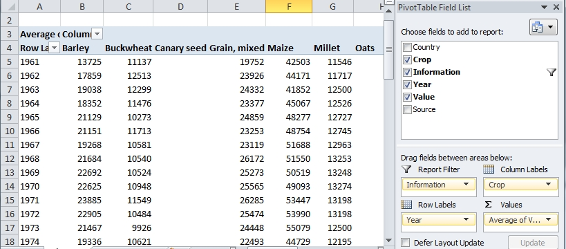

Manny Gimond (2015)